# 5143135: Computer Graphics @ ZJU School of Software Technology

## Lab 1: Fundamentals of OpenGL with Python

Welcome to **5143135: Computer Graphics**!  
This course focuses on a range of interesting and useful topics in *computer graphics* (CG), and meanwhile highly programming-based. Therefore, upon your enrolment, you are assumed to have at least entry-level knowledge in *object-oriented programming* (OOP) with Python.  
If your answer to the above assumption is **NO**, I recommend that you practice OOP with Python as much as possible in your spare time.  
After attending this lab class, you are expected to

- Distinguish OpenGL and its utilities;
- Understand the framework of an OpenGL window application; and
- Write a Python program with PyOpenGL that displays simple polygons and polylines.

### Part 1: OpenGL and its utilities

**OpenGL** is a cross-language, cross-platform application programming interface (API) for rendering 2D and 3D vector graphics. The API is typically used to interact with a graphics processing unit, to achieve hardware-accelerated rendering. The figure below llustrates the graphics pipeline process.

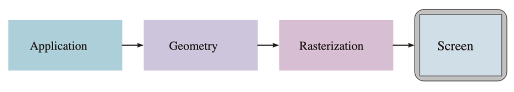

Throughout the course, we will understand this pipeline step-by-step by programming to accomplish a series of fundamental CG tasks. The names of OpenGL functions start with *gl* and enums (custom identifiers) with *GL_*.

Although OpenGL serves as a powerful and efficient API for CG purposes, it has always been regarded *low-level* for application development. Hence some utilities were proposed to facilitate the programming, as follows:

- **OpenGL Utility Library (GLU)** is a set of functions to create texture mipmaps from a base image, map coordinates between screen and object space, and draw quadric surfaces. The names of GLU functions start with *glu*;
- **OpenGL Utility Toolkit (GLUT)** is a window system independent toolkit for writing OpenGL programs. It implements a simple windowing API for OpenGL. The names of GLUT functions start with *glut*.

### Part 2: Install PyOpenGL

Although OpenGL is cross-language, most developers prefer **C++** as the programming language for it effciency and the massive references. In the course, however, we use **Python** to accomplish the OpenGL programming tasks, because artificial intelligence (AI) has nowadays become close to CG and, consequently, Python is more popular among programmers.

**PyOpenGL** is the most common cross platform Python binding to OpenGL and related APIs. The binding is created using the standard ctypes library, and is provided under an extremely liberal BSD-style Open-Source license.

To work with PyOpenGL, you must ensure that your Python's version is above *3.3*. All examples in the course was written and tested with Python *3.8.1*.

To install PyOpenGL, please follow the instructions below according to your operating system:

- **Mac OS X / Linux**:
  1. If working with a native Python, please use **pip** command as
     - pip install PyOpenGL PyOpenGL_accelerate
  2. If working with a **Conda**-based package (e.g., Anaconda, Miniconda), please use **conda** command as
     - conda install PyOpenGL PyOpenGL_accelerate
- **Windows 7 / 8 / 10 / 11**:
  1. You are highly recommended to work with a native Python, and access the following url
     - https://www.lfd.uci.edu/~gohlke/pythonlibs/#pyopengl  
       and download the following two .whl files
     - PyOpenGL‑3.1.6‑cp**AB**‑cp**AB**‑**win_amd64**.whl
     - PyOpenGL_accelerate‑3.1.6‑cp**AB**‑cp**AB**‑**win_amd64**.whl  
       where **A** is the Python's major version, and **B** the minor version (e.g., if the version is 3.8.1, then AB is 38). If your Python is 32-bit, please replace **win_amd64** with **win32**.
  2. Having the two .whl files, use **pip** command as
     - pip install path_to_the_whl_file.whl

You can verify if the installation is successful using the following Python codes. Zero-error means you are good to go!

```python
from OpenGL.GL import *
from OpenGL.GLUT import *
from OpenGL.GLU import *
```

As you may know, the codes import OpenGL, GLU and GLUT packages to the Python program, which you can work with to build an OpenGL application.

### Part 3: OpenGL window application framework

In the modeling tasks, we focus on the **Geometry** stage mentioned in the pipeline. It can be further into more steps illustrated in the figure below.

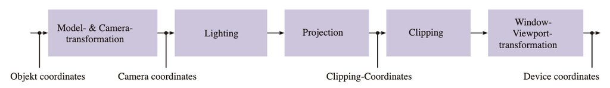

Therefore, we usually write a program for an OpenGL application as follows:

1. **Initialize GLUT and display mode.**

```python
glutInit()                                  # Initialize GLUT
glutInitDisplayMode(GLUT_RGB |              # Set the display mode to be colored (red, green, blue)
                    GLUT_DOUBLE |           # Set the display mode to be double-buffered (for animation)
                    GLUT_DEPTH)             # Set the display mode to be with a depth buffer
```

1. **Initialize the window.** This step creates a window of size (width, height) or *(w, h)*, located at *(u, v)* in the screen coordinate system. Note that, for a screen coordinate system, the origin is the **upper-left** corner of the screen. Hence, *u* refers to distance from the upper of the window from the upper boundary of the screen, and *v* the distance from the left of the window from the left boundary of the screen. You may also give the window a title when creating it.

```python
glutInitWindowSize(w, h)                    # Set width and height of the window
glutInitWindowPosition(u, v)                # Set the position (upper-left) of the window
glutCreateWindow("Window title")            # Set the title and create the window
```

1. **Iniialize the rendering settings.** This is usually a **user-defined** function, includig a series of settings on rendering (e.g., *lighting*, *depth*). We will discuss it later in details.

```python
def initRendering():
    glEnable(GL_DEPTH_TEST)                 # Enable depth testing
    #glEnable(GL_LIGHTING)                  # Enable lighting calculations
    #glEnable(GL_LIGHT0)                    # Enable the 0-th light

initRendering()
```

1. **Register a function about the window's resizing.** A **user-defined** function is passed as an argument to the GLUT function, which deals with *viewport* and *projection* after the window is resized.

```python
def reshape(w, h):
    glViewport(0, 0, w, h)                  # Set up the viewport (i.e., the visible area in the window)

    glMatrixMode(GL_PROJECTION)             # Change matrix mode for projection
    glLoadIdentity()                        # Replace the current matrix with the identity matrix
    glOrtho(0.0, w, 0.0, h, 0.0, 1.0)       # Set up a orthogonal projection (left, right, botton, top, nearVal, farVal)
    glMatrixMode(GL_MODELVIEW)              # Change matrix mode for modelview (e.g., modeling)
    glLoadIdentity()                        # Replace the current matrix with the identity matrix

glutReshapeFunc(reshape, w, h)
```

1. **Register a function about the window's redrawing.** A **user-defined** function is passed as an argument to the GLUT function, which deals with the window's redrawing. This function is exactly where you do **modeling** (i.e., draw the desired objects), and is called only when the program forces the window to redraw (i.e., not self-updating).

```python
def display():

    glClear(GL_COLOR_BUFFER_BIT |
            GL_DEPTH_BUFFER_BIT)            # Remove everything from screen (i.e. displays all blank)
    glLoadIdentity()                        # Reset all objects' positions

    # draw something here

    glutSwapBuffers()                       # Perform a buffer swap on the layer in use for the current window.

glutDisplayFunc(display)
```

1. **Register a function about the window's idle status.** A **user-defined** function is passed as an argument to the GLUT function, which sets the global idle callback so a GLUT program can perform background processing tasks or continuous animation when window system events are not being received. If enabled, the idle callback is continuously called when events are not being received. **At the moment, you may regard it as where you enable an animation.** After this GLUT function, we usually add another one to keep the window displaying.

```python
def idle():
    display()

glutIdleFunc(idle)
glutMainLoop()                               # Keep the window displaying in a loop
```

### Part 4: Draw simple polygons and polylines with PyOpenGL

After having an overview on OpenGL and the basic steps to develop a window application, let's try draw some simple polygons and polylines with PyOpenGL. Suppose the window has a width of *500* (pixels) and a height of *500* (pixels), and its upperleft corner is at (100, 100), our tasks are as follows:

1. Draw a square (side = 100) with only a white borderline, placed at the center of the window;
2. Fill the square in Task 1 with white color; and
3. Fill the square in Task 2 with colors mixed by those of the four vertices.

#### Task 1

At the very beginning, we need to declare and assign values to the four variables on window's shape and position before all OpenGL functions.

```python
w, h = 500, 500
u, v = 100, 100
```

Then we head back to and improve the **display** function. The projection coordinate system of the window is different from the screen coordinate system. Its origin is the **lower-left** corner of the window. Therefore, the coordinate of lower-left window is (0, 0) and that of upper-right window is (500, 500), making the center at (250, 250).

Now we can calculate the coordinates for the four vertices constituting the square: (200, 200), (300, 200), (300, 300) and (200, 300). The function is updated as follows.

```python
def display():

    glClear(GL_COLOR_BUFFER_BIT |
            GL_DEPTH_BUFFER_BIT)            # Remove everything from screen (i.e. displays all blank)
    glLoadIdentity()                        # Reset all objects' positions

    glBegin(GL_LINE_LOOP)                   # Begin drawing
    glColor3f(1.0, 1.0, 1.0)
    glVertex2f(200, 200)
    glVertex2f(200, 300)
    glVertex2f(300, 300)
    glVertex2f(300, 200)
    glEnd()                                 # End drawing

    glutSwapBuffers()                       # Perform a buffer swap on the layer in use for the current window.
```

To draw an object, we use *glBegin* and *glEnd*. The argument passed to glBegin determines the type of object (geometric primitive) to be drawn. Please refer to the figure below for the options and their meanings.

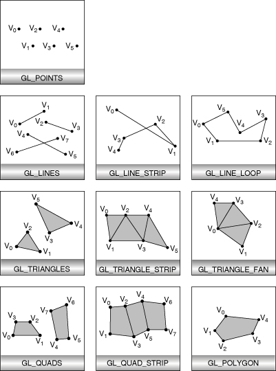

Between *glBegin* and *glEnd*, *glVertex* is called four times to input the coordinates of the vertices. Note the postfix of glVertex, **2f**, refers to 2-dimentional and float. As you can see, *glColor* is called before the first vertex (what about the postfix **3f**?). The three coordinates correspond to the red, green, and blue channels. Hence, *glColor3f(1.0, 1.0, 1.0)* sets the current color to *white*.

Now, please organize the program as follows and run it.

```python
from OpenGL.GL import *
from OpenGL.GLUT import *
from OpenGL.GLU import *


def display():
    glClear(GL_COLOR_BUFFER_BIT | GL_DEPTH_BUFFER_BIT)
    glLoadIdentity()

    glBegin(GL_LINE_LOOP)
    glColor3f(1.0, 1.0, 1.0)
    glVertex2f(200, 200)
    glVertex2f(200, 300)
    glVertex2f(300, 300)
    glVertex2f(300, 200)
    glEnd()

    glutSwapBuffers()


def idle():
    display()


def initRendering():
    glEnable(GL_DEPTH_TEST)
    # glEnable(GL_LIGHTING)
    # glEnable(GL_LIGHT0)


def reshape(w, h):
    glViewport(0, 0, w, h)

    glMatrixMode(GL_PROJECTION)
    glLoadIdentity()
    glOrtho(0.0, w, 0.0, h, 0.0, 1.0)

    glMatrixMode(GL_MODELVIEW)
    glLoadIdentity()


w, h = 500, 500
u, v = 100, 100

glutInit()
glutInitDisplayMode(GLUT_RGB |
                    GLUT_DOUBLE |
                    GLUT_DEPTH)

glutInitWindowSize(w, h)
glutInitWindowPosition(u, v)
glutCreateWindow("Lab 01")

initRendering()

glutReshapeFunc(reshape, w, h)
glutDisplayFunc(display)
glutIdleFunc(idle)
glutMainLoop()
```

If everything is working well, you are supposed to see the following window that appears in the upper-left area of the screen.

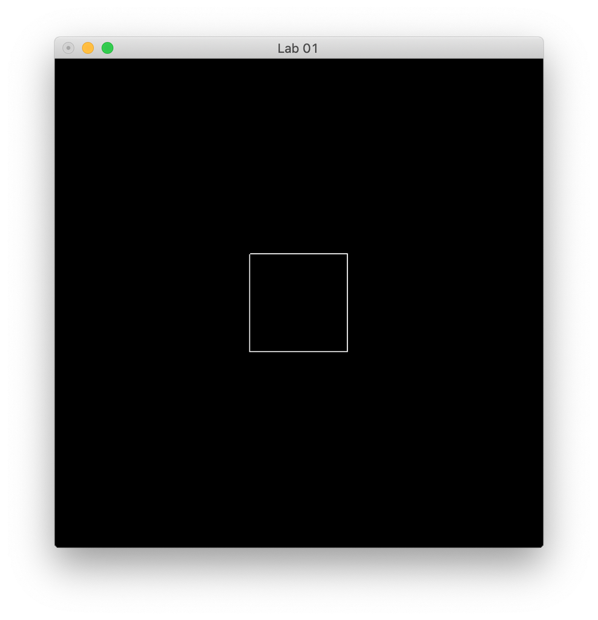

#### Task 2

Our job now is to fill the square with white color. Recall what we just discussed about *glBegin* and its argument choices. Do you have any clue? (If not, go back to check the geometric primitive figure.)

If you are considering replacing *GL_LINE_LOOP* with something else, congratulations! That is the answer and we should use *GL_QUADS* this time.

Update *display* function as follows.

```python
def display():
    glClear(GL_COLOR_BUFFER_BIT | GL_DEPTH_BUFFER_BIT)
    glLoadIdentity()

    glBegin(GL_QUADS)
    glColor3f(1.0, 1.0, 1.0)
    glVertex2f(200, 200)
    glVertex2f(200, 300)
    glVertex2f(300, 300)
    glVertex2f(300, 200)
    glEnd()

    glutSwapBuffers()
```

Run the program and you will get a window displying a white square as in the following figure.

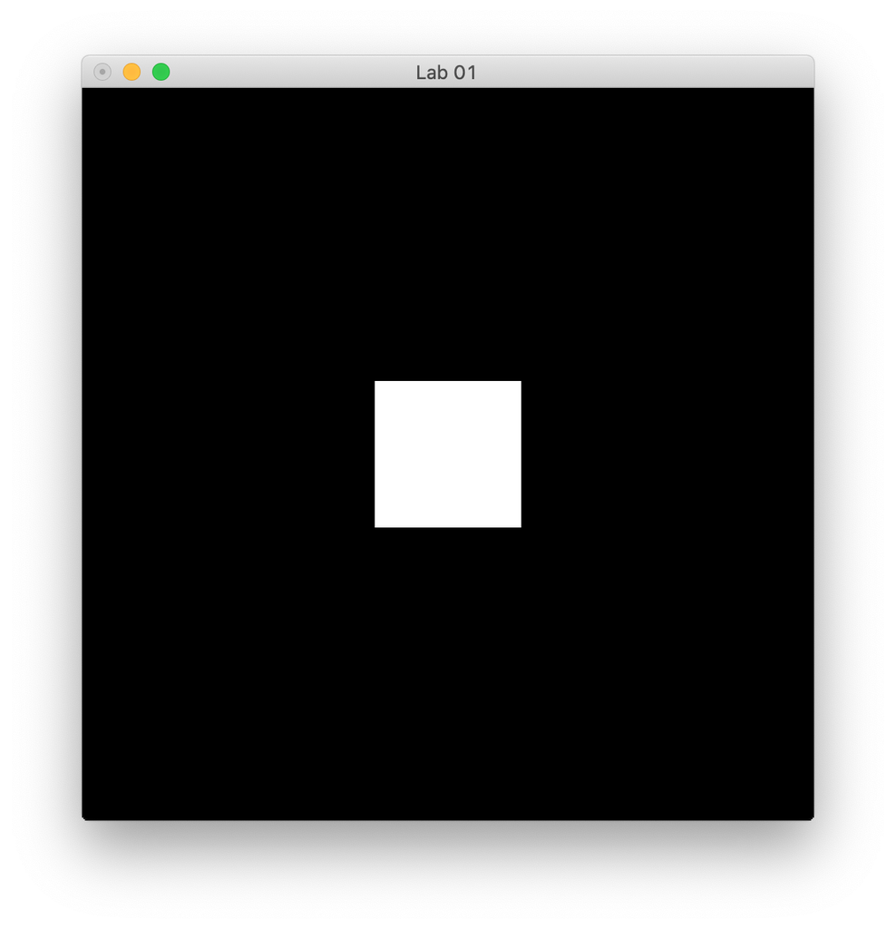

#### Task 3

Now let's play more with colors. Suppose we would like the square to filled with mixed colors based on those of the four vertices. The solution is straightforward: add a color to each of the vertices, like what we did to the first vertex in Task 1 and 2.

```python
def display():
    glClear(GL_COLOR_BUFFER_BIT | GL_DEPTH_BUFFER_BIT)
    glLoadIdentity()

    glBegin(GL_QUADS)
    glColor3f(1.0, 0.0, 0.0)
    glVertex2f(200, 200)
    glColor3f(0.0, 1.0, 0.0)
    glVertex2f(200, 300)
    glColor3f(0.0, 0.0, 1.0)
    glVertex2f(300, 300)
    glColor3f(1.0, 0.0, 1.0)
    glVertex2f(300, 200)
    glEnd()

    glutSwapBuffers()
```

Run the program and you will get a window displying a colorful square as in the following figure. Note the inside are of the square is colored with weighted sum of the colors of the four vertices.

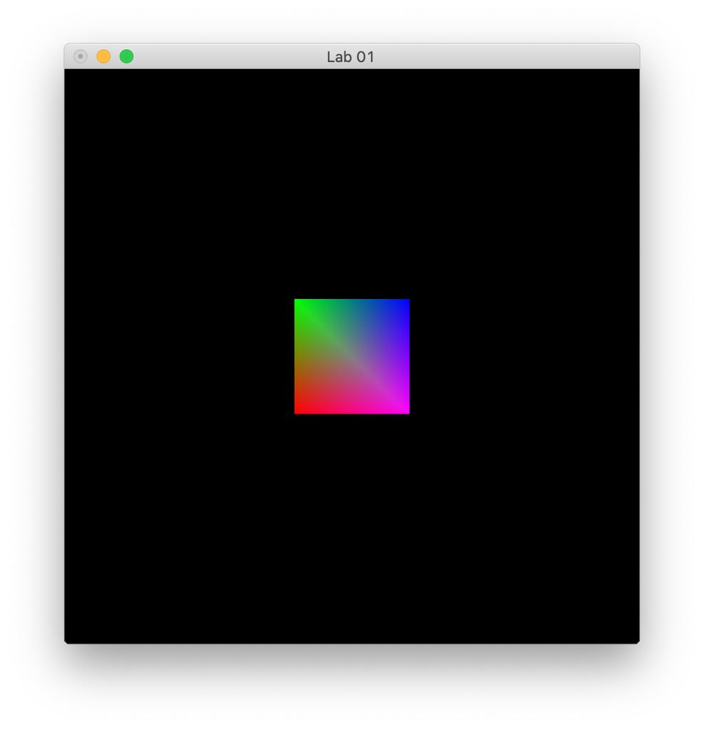

### Questions

#### Q1: Write a Python program with PyOpenGL to display a circle filled with the transition of red colors as in the following figure. The ceters of the circle and the window are same. The radius of the circle is 100 pixels.

- Think about how to (1) draw or rather *approximate* a circle, and (2) calculate an appropriate color assigned to each vertex?

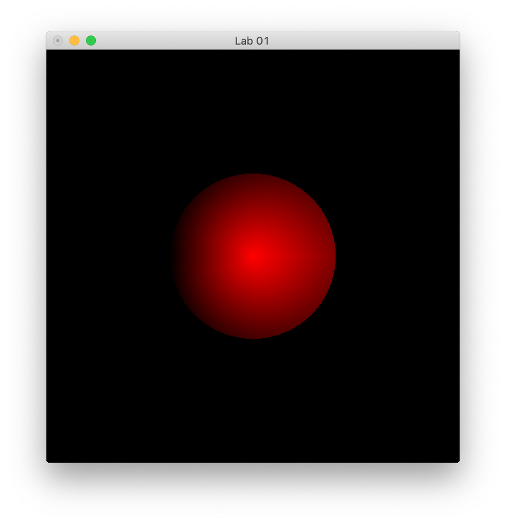

- Think about how to calculate the coordinates of the vertices.

[figure not shown]

#### A sample solution is to be provided ONE day after the lab on the DingTalk group :)